# ep04

```python
name = "Arthur Font Gouveia"  # write YOUR NAME
honorPledge = "I affirm that I have not given or received any unauthorized " \
              "help on this assignment, and that this work is my own.\n"

print("\nName: ", name)
print("\nHonor pledge: ", honorPledge)
```

```
Name:  Arthur Font Gouveia

Honor pledge:  I affirm that I have not given or received any unauthorized help on this assignment, and that this work is my own.
```

```python
import numpy as np
import matplotlib.pyplot as plt
from tensorflow.keras.datasets import mnist
%matplotlib inline
```

```python
(X_train_ori, y_train_ori), (X_test_ori, y_test_ori) = mnist.load_data()

print(X_train_ori.shape, y_train_ori.shape)
print(X_test_ori.shape, y_test_ori.shape)
```

```
(60000, 28, 28) (60000,)
(10000, 28, 28) (10000,)
```

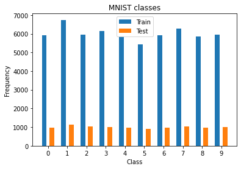

```python
labels = ["%s"%i for i in range(10)]

unique, counts = np.unique(y_train_ori, return_counts=True)
uniquet, countst = np.unique(y_test_ori, return_counts=True)

fig, ax = plt.subplots()
rects1 = ax.bar(unique - 0.2, counts, 0.25, label='Train')
rects2 = ax.bar(unique + 0.2, countst, 0.25, label='Test')
ax.legend()
ax.set_xticks(unique)
ax.set_xticklabels(labels)

plt.title('MNIST classes')
plt.xlabel('Class')
plt.ylabel('Frequency')
plt.show()
```

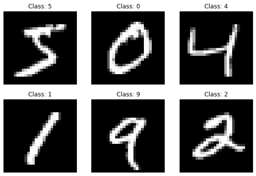

```python
fig, ax = plt.subplots(2, 3, figsize = (9, 6))

for i in range(6):
    ax[i//3, i%3].imshow(X_train_ori[i], cmap='gray')
    ax[i//3, i%3].axis('off')
    ax[i//3, i%3].set_title("Class: %d"%y_train_ori[i])

plt.show()
```

```python
# Reduce the image size to its half
X_train = np.array([image[::2, 1::2] for image in X_train_ori])
X_test  = np.array([image[::2, 1::2] for image in X_test_ori])

y_train = y_train_ori
y_test = y_test_ori
```

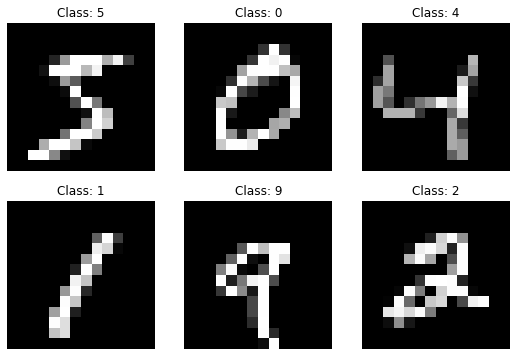

```python
fig, ax = plt.subplots(2, 3, figsize = (9, 6))

for i in range(6):
    ax[i//3, i%3].imshow(X_train[i], cmap='gray')
    ax[i//3, i%3].axis('off')
    ax[i//3, i%3].set_title("Class: %d"%y_train_ori[i])

plt.show()
```

```python
X_train = (X_train/255.0).astype('float32').reshape((60000,14*14))
X_test = (X_test/255.0).astype('float32').reshape((10000,14*14))

print(X_train.dtype)
print(X_test.dtype)

print("\nShape of X_train: ", X_train.shape)
print("Shape of X_test: ", X_test.shape)

print("\nMinimum value in X_train:", np.amin(X_train))
print("Maximum value in X_train:", np.amax(X_train))

print("\nMinimum value in X_test:", np.amin(X_test))
print("Maximum value in X_test:", np.amax(X_test))
```

```
float32
float32

Shape of X_train:  (60000, 196)
Shape of X_test:  (10000, 196)

Minimum value in X_train: 0.0
Maximum value in X_train: 1.0

Minimum value in X_test: 0.0
Maximum value in X_test: 1.0
```

## 1. Dataset preparation

### 1.1 Split original training set into 70% training (D_train) and 30% validation (D_val) sets, in a stratified way

Scikit Documentation: https://scikit-learn.org/stable/modules/generated/sklearn.model_selection.train_test_split.html

```python
from sklearn.model_selection import train_test_split
from collections import Counter
import warnings
warnings.filterwarnings("ignore")
DX_train, DX_val, Dy_train, Dy_val = train_test_split(X_train, y_train, test_size=0.3, stratify = y_train)
```

```python
print("D_train shape:", DX_train.shape)
print("D_val shape:", DX_val.shape)
```

```
D_train shape: (42000, 196)
D_val shape: (18000, 196)
```

### 1.2 Make sure that the generated partition is indeed stratified.

```python
dic_train = Counter(Dy_train)
dic_val = Counter(Dy_val)
for i in unique:
    print("Distribution of class {} on train set: {:.2%}".format(i, dic_train[i]/(dic_train[i] + dic_val[i])))
print("- Conclusion: The generated partition is indeed stratified  (≅ 70.00%).")
```

```
Distribution of class 0 on train set: 70.00%
Distribution of class 1 on train set: 69.99%
Distribution of class 2 on train set: 70.01%
Distribution of class 3 on train set: 70.00%
Distribution of class 4 on train set: 69.99%
Distribution of class 5 on train set: 70.01%
Distribution of class 6 on train set: 70.01%
Distribution of class 7 on train set: 69.99%
Distribution of class 8 on train set: 70.01%
Distribution of class 9 on train set: 69.99%
- Conclusion: The generated partition is indeed stratified  (≅ 70.00%).
```

## 2. Training, evaluating and selecting models

=> I used the method train_test_split() from model selection of scikit-learn to use a reduced sample (1/3 of the train data set). I also applied combinations to select the best hyparameters for each model.  
Scikit Documentation: https://scikit-learn.org/stable/model_selection.html  
Other references: https://machinelearningmastery.com/hyperparameters-for-classification-machine-learning-algorithms/#:~:text=Logistic%20regression%20does%20not%20really,with%20different%20solvers%20(solver).&text=Regularization%20(penalty)%20can%20sometimes%20be%20helpful.

```python
from sklearn.model_selection import StratifiedKFold
import itertools

# Parameters seted for reduce processing time and CPU's resources
MAX_ITER = 20

# Partition on D_train was needed because of the large size of data to be processed
reduced_x_train, x_n, reduced_y_train, x_y = train_test_split(DX_train, Dy_train, test_size=0.66, stratify = Dy_train)
dic_train = Counter(reduced_y_train)
dic_val = Counter(x_y)
for i in unique:
    print("Distribution of class {} on train set: {:.2%}".format(i, dic_train[i]/(dic_train[i] + dic_val[i])))
print("- Conclusion: The generated partition is indeed stratified (≅ 33.99%).")
```

```
Distribution of class 0 on train set: 34.01%
Distribution of class 1 on train set: 33.99%
Distribution of class 2 on train set: 34.00%
Distribution of class 3 on train set: 33.99%
Distribution of class 4 on train set: 33.99%
Distribution of class 5 on train set: 33.99%
Distribution of class 6 on train set: 34.01%
Distribution of class 7 on train set: 34.00%
Distribution of class 8 on train set: 34.01%
Distribution of class 9 on train set: 34.01%
- Conclusion: The generated partition is indeed stratified (≅ 33.99%).
```

### 2.1 Logistic regression model

=> I evaluated the following hypeparameters for the logistic regression model:

- Solver: algorithm to use in the optimization problem
- Penalty: norm used in the penalization
- C: inverse of regularization strength

Scikit Documentation: https://scikit-learn.org/stable/modules/generated/sklearn.linear_model.LogisticRegression.html

```python
from sklearn.linear_model import LogisticRegression

# Define hyperparameters
solvers = ['newton-cg', 'lbfgs', 'liblinear']
penalty = ['l2']
c_values = [10, 1.0, 0.1]

# Combination of hyparameters
comb_params = list(itertools.product(solvers, penalty, c_values))
i = 0
for p in comb_params:
    clf = LogisticRegression(solver=p[0], penalty=p[1], C=p[2], max_iter=MAX_ITER)
    clf.fit(reduced_x_train, reduced_y_train)

    # Get scores for each combination of hyparameters
    train_acc = clf.score(reduced_x_train, reduced_y_train)
    print("{}: Train set acc: {:.2%} with:".format(i+1, train_acc), p)
    i += 1
```

```
1: Train set acc: 92.50% with: ('newton-cg', 'l2', 10)
2: Train set acc: 92.00% with: ('newton-cg', 'l2', 1.0)
3: Train set acc: 90.65% with: ('newton-cg', 'l2', 0.1)
4: Train set acc: 90.39% with: ('lbfgs', 'l2', 10)
5: Train set acc: 90.39% with: ('lbfgs', 'l2', 1.0)
6: Train set acc: 90.13% with: ('lbfgs', 'l2', 0.1)
7: Train set acc: 91.37% with: ('liblinear', 'l2', 10)
8: Train set acc: 90.74% with: ('liblinear', 'l2', 1.0)
9: Train set acc: 89.55% with: ('liblinear', 'l2', 0.1)
```

### 2.2 SVM model

=> I evaluated the following hypeparameters for the SVM model:

- Penalty: norm used in the penalization
- C: inverse of regularization strength

Scikit Documentation: https://scikit-learn.org/stable/modules/generated/sklearn.svm.LinearSVC.html#sklearn.svm.LinearSVC

```python
from sklearn.svm import LinearSVC

# Define hyperparameters
penalty = ['l1', 'l2']
c_values = [10, 1.0, 0.1]

# Combination of hyparameters
comb_params = list(itertools.product(penalty, c_values))
i = 0
for p in comb_params:
    clf = LinearSVC(penalty=p[0],C=p[1],dual=False, max_iter=MAX_ITER)
    clf.fit(reduced_x_train, reduced_y_train)

    # Get scores for each combination of hyparameters
    train_acc = clf.score(reduced_x_train, reduced_y_train)
    print("{}: Train set acc: {:.2%} with:".format(i+1, train_acc), p)
    i += 1
```

```
1: Train set acc: 91.10% with: ('l1', 10)
2: Train set acc: 90.88% with: ('l1', 1.0)
3: Train set acc: 90.11% with: ('l1', 0.1)
4: Train set acc: 91.08% with: ('l2', 10)
5: Train set acc: 90.94% with: ('l2', 1.0)
6: Train set acc: 90.60% with: ('l2', 0.1)
```

### 2.3 Neural network model

=> I evaluated the following hypeparameters for the neural network model:

- Hidden layer sizes: number of neurons on each hidden layer
- Solver: solver for weight optimization
- Activation: activation function for the hidden layer

Scikit Documentation: https://scikit-learn.org/stable/modules/generated/sklearn.neural_network.MLPClassifier.html

```python
from sklearn.neural_network import MLPClassifier

# Define hyperparameters
hidden_layer_sizes = [50, 100, 150]
solvers = ['lbfgs', 'sgd', 'adam']
activation = ['identity', 'logistic', 'tanh', 'relu']

# Combination of hyparameters
comb_params = list(itertools.product(hidden_layer_sizes, solvers, activation))
i = 0
for p in comb_params:
    clf = MLPClassifier(hidden_layer_sizes=p[0], solver=p[1], activation=p[2], max_iter=MAX_ITER)
    clf.fit(reduced_x_train, reduced_y_train)

    # Get scores for each combination of hyparameters
    train_acc = clf.score(reduced_x_train, reduced_y_train)
    print("{}: Train set acc: {:.2%} with:".format(i+1, train_acc), p)
    i += 1
```

```
1: Train set acc: 90.04% with: (50, 'lbfgs', 'identity')
2: Train set acc: 87.36% with: (50, 'lbfgs', 'logistic')
3: Train set acc: 92.07% with: (50, 'lbfgs', 'tanh')
4: Train set acc: 88.76% with: (50, 'lbfgs', 'relu')
5: Train set acc: 83.82% with: (50, 'sgd', 'identity')
6: Train set acc: 54.98% with: (50, 'sgd', 'logistic')
7: Train set acc: 83.49% with: (50, 'sgd', 'tanh')
8: Train set acc: 83.54% with: (50, 'sgd', 'relu')
9: Train set acc: 91.75% with: (50, 'adam', 'identity')
10: Train set acc: 91.02% with: (50, 'adam', 'logistic')
11: Train set acc: 93.27% with: (50, 'adam', 'tanh')
12: Train set acc: 94.01% with: (50, 'adam', 'relu')
13: Train set acc: 89.82% with: (100, 'lbfgs', 'identity')
14: Train set acc: 85.45% with: (100, 'lbfgs', 'logistic')
15: Train set acc: 91.62% with: (100, 'lbfgs', 'tanh')
```

[output cut: 21 more lines]

### 2.4 Clearly indicate and justify the selected three models

=> Logistic Regression:

- Solver = newton-cg
- Penalty = l2
- C = 10

=> MLP (Neural network):

- Hidde layer sizes = 150
- Solver = adam
- Activation = relu

```python
# Best parameter reached for each model
p_LogReg = ['newton-cg', 'l2', 10] # solver, penalty, C
p_LinSVC = ['l2', 1.0] # penalty, C
p_MLP = [150, 'adam', 'relu'] # hidden_layer_sizes, solver, activation
```

## 3. Choosing a final model

### 3.1 Evaluate each model on validation set

```python
# Logistic Regression model
clf = LogisticRegression(solver=p_LogReg[0], penalty=p_LogReg[1], C=p_LogReg[2], max_iter=MAX_ITER)
clf.fit(DX_train, Dy_train)
val_acc = clf.score(DX_val, Dy_val)
print("Validation set acc: {:.2%} with:".format(val_acc), p_LogReg)
```

```
Validation set acc: 90.97% with: ['newton-cg', 'l2', 10]
```

```python
# Linear SVC model
clf = LinearSVC(penalty=p_LinSVC[0],C=p_LinSVC[1],dual=False, max_iter=MAX_ITER)
clf.fit(DX_train, Dy_train)
val_acc = clf.score(DX_val, Dy_val)
print("Validation set acc: {:.2%} with:".format(val_acc), p_LinSVC)
```

```
Validation set acc: 89.97% with: ['l2', 1.0]
```

```python
# MLP model
clf = MLPClassifier(hidden_layer_sizes=p_MLP[0], solver=p_MLP[1], activation=p_MLP[2], max_iter=MAX_ITER)
clf.fit(DX_train, Dy_train)
val_acc = clf.score(DX_val, Dy_val)
print("Validation set acc: {:.2%} with:".format(val_acc), p_MLP)
```

```
Validation set acc: 96.78% with: [150, 'adam', 'relu']
```

### 3.2 Find the best model

=> MLP (Neural network) hyperparameters:

- Hidden layer sizes = 150. Our network has a single hidden layer with 150 neurons because of computer resources. It's expected that with more neurons and more layers the algorithm will perform even better.
- Solver = adam. Refers to a stochastic gradient-based optimizer proposed by Kingma, Diederik, and Jimmy.
- Activation = relu. The rectified linear unit function, returns f(x) = max(0, x)

## 4 Error estimation

Scikit Documentation: https://scikit-learn.org/stable/modules/generated/sklearn.metrics.classification_report.html  
https://scikit-learn.org/stable/modules/generated/sklearn.metrics.plot_confusion_matrix.html

### 4.1 Evaluate each model on test set

```python
# MLP model
clf = MLPClassifier(hidden_layer_sizes=p_MLP[0], solver=p_MLP[1], activation=p_MLP[2], max_iter=MAX_ITER)
clf.fit(DX_train, Dy_train)
test_acc = clf.score(X_test, y_test)
print("Test set acc: {:.2%} with:".format(test_acc), p_MLP)
```

```
Test set acc: 97.13% with: [150, 'adam', 'relu']
```

```python
from sklearn.metrics import classification_report
y_test_pred = clf.predict(X_test)
print(classification_report(y_test, y_test_pred, digits=5))
```

```
              precision    recall  f1-score   support

           0    0.96912   0.99286   0.98085       980
           1    0.98763   0.98502   0.98633      1135
           2    0.97635   0.96027   0.96825      1032
           3    0.96955   0.97723   0.97337      1010
           4    0.96285   0.97658   0.96967       982
           5    0.98282   0.96188   0.97224       892
           6    0.97280   0.97077   0.97179       958
           7    0.96239   0.97082   0.96659      1028
           8    0.95594   0.95791   0.95692       974
           9    0.97281   0.95738   0.96503      1009

    accuracy                        0.97130     10000
   macro avg    0.97123   0.97107   0.97110     10000
weighted avg    0.97137   0.97130   0.97129     10000
```

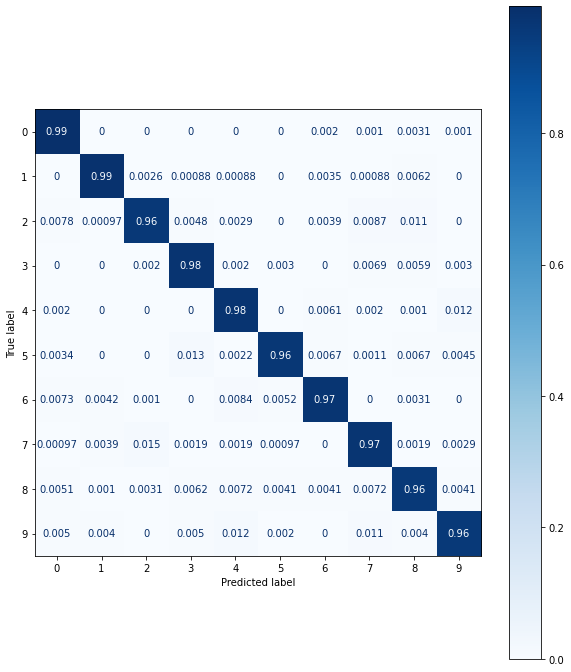

```python
from sklearn.metrics import plot_confusion_matrix
import matplotlib.pyplot as plt
fig, ax = plt.subplots(figsize = (10, 12))
plot_confusion_matrix(clf, X_test, y_test, ax=ax, normalize='true', cmap=plt.cm.Blues)
plt.show()
```

### 4.2 Retrain the selected model on Dtrain ∪ Dval and verify if there is any significant difference.

=> After retrain the selected model with the train set and the validation set, the model showed an even better performance. This can be explained by a relevant increase in real data in the training phase.

```python
# Retrained MLP model
clf = MLPClassifier(hidden_layer_sizes=p_MLP[0], solver=p_MLP[1], activation=p_MLP[2], max_iter=MAX_ITER)
clf.fit(X_train, y_train)
test_acc = clf.score(X_test, y_test)
print("(Retrained) Test set acc: {:.2%} with:".format(test_acc), p_MLP)
```

```
(Retrained) Test set acc: 97.52% with: [150, 'adam', 'relu']
```

```python
y_test_pred = clf.predict(X_test)
print(classification_report(y_test, y_test_pred, digits=5))
```

```
              precision    recall  f1-score   support

           0    0.98374   0.98776   0.98574       980
           1    0.98252   0.99031   0.98640      1135
           2    0.96190   0.97868   0.97022      1032
           3    0.97522   0.97426   0.97474      1010
           4    0.97857   0.97658   0.97757       982
           5    0.98303   0.97422   0.97860       892
           6    0.97599   0.97599   0.97599       958
           7    0.97645   0.96790   0.97215      1028
           8    0.96591   0.95996   0.96292       974
           9    0.96912   0.96432   0.96672      1009

    accuracy                        0.97520     10000
   macro avg    0.97525   0.97500   0.97511     10000
weighted avg    0.97521   0.97520   0.97519     10000
```

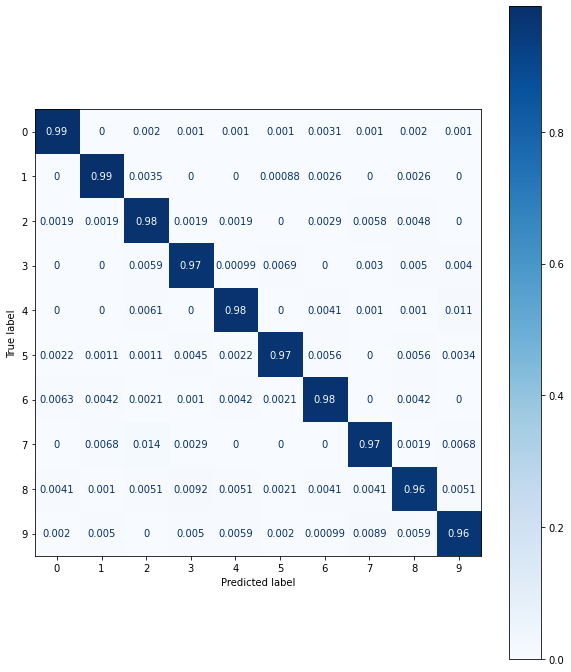

```python
fig, ax = plt.subplots(figsize = (10, 12))
plot_confusion_matrix(clf, X_test, y_test, ax=ax, normalize='true', cmap=plt.cm.Blues)
plt.show()
```

=> The multilayer perceptron classifier had 97,52% of accuracy. Therefore this model proved to be able to solve the problem approached (MNIST).